# Bovary

# [Staatsballett Berlin](https://www.staatsballett-berlin.de/)

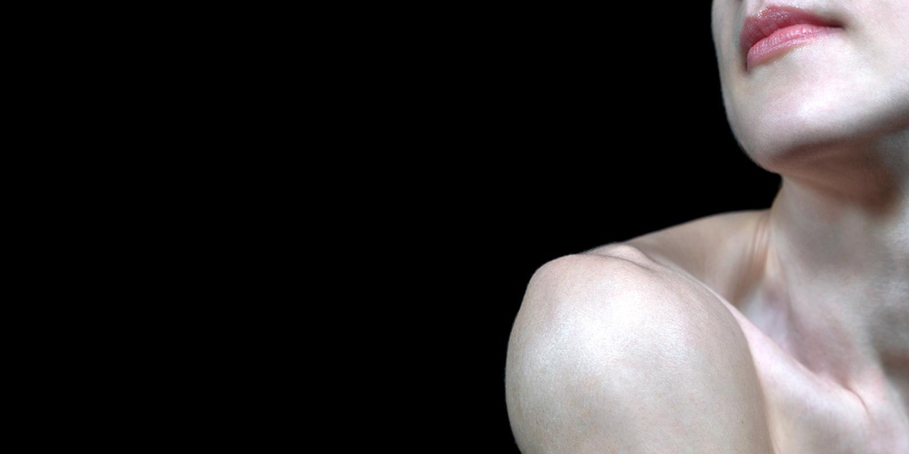

TU 31.10.2023, 7.30 PM

# Bovary

Choreography by Christian Spuck after the novel by Gustave Flaubert  
Music by Camille Saint-Saëns, Thierry Pécou, György Ligeti u.a.

[Gallery](https://www.staatsballett-berlin.de/media/img/3/4271/Bovary.jpg)

Gustave Flaubert’s novel Madame Bovary is a masterpiece of world literature that paved the way for modernism. When it was published in 1856, a scandal ensued. Flaubert was accused of «glorifying adultery» and charged with «violating public and religious morality and decency». The novel tells the story of a young country woman who wants much more than a suffocating provincial life at the side of her petit-bourgeois, unambitious husband. Emma Bovary rebels against her marriage, takes on lovers, loses herself in dreams of passion, luxury and debauchery – and it ends in disaster. She falls hopelessly into debt, ruins her family and finally takes a fatal dose of poison.

‹Bovarism›, a condition in which a person denies reality, is named after the protagonist of Flaubert’s famous novel: Emma Bovary escapes from her dull life in the provinces through excessive fantasies, which she cultivates by reading romantic novels and Parisian fashion magazines. Her extramarital affairs mirror this kitsch, fantasy world, as she lives beyond her means and loses sight of reality.

Measured against its literary fame, Madame Bovary is rarely performed on stage, particularly as a ballet. Flaubert’s narrative style seems too cool and realistic for a stage adaptation. But precisely his detached, accurate language, combined with his total engagement with his subject matter, makes it so inspiring. The female figure as an outsider is at the centre of this new production, which does not tell Madame Bovary as a conventional story ballet but instead breaks up narrative structures and approaches the material through abstract choreography and intimate psychological observation. At the same time, it never loses sight of the tale.

Christian Spuck’s dance piece Bovary is about the search for female self-determination, rapture and loneliness, substitutions for love, self-injury, hedonism and the fatal outcome when fantasy worlds and reality merge into one. The concept for this new production by the Staatsballett Berlin is to adapt the literary material using darkly poetic imagery and refined humour – to tell the story, not for the sake of telling it, but to enter the characters’ inner worlds and transform them into dance.

C2 (€24-100)

**90 Minuten** **ohne Pause**

### Further events

[figure not shown]

[interactive chart not shown]